# Project: Investigate a Dataset - [The Movie Database]

- Introduction
- Data Wrangling
- Exploratory Data Analysis
- Question 1
- Question 2
- Question 3
- Conclusions

## Introduction

### Dataset Description

> This data set contains information about 10,000 movies collected from The Movie Database (TMDb), including user ratings and revenue.

**id** : unique id of the movie in the dataset- provides no information (propably will be dropped)  
**imdb_id**: imdb id (probably will be dropped  
**popularity**: a quantifiable measure of popularity on a scale that goes from zero to around 32 for the highest value  
**budget**: reported budget of the movie  
**revenue** : reported revenue of the movie including merchandise and copywrites associated with the movie  
**original_title**: the title of the movie  
**cast**: cast names of the first 5 actors in the cast separated by '|'. Will probably need cleaning  
**homepage**: a website link for the movies, most of them don't have it (probably will be dropped)  
**director**: the name of the director, some small number have more than 1 director separated by '|'  
**tagline**: a catchy line that holds the essense of the movie ( probably will be dropped)  
**overview**: a short description of the movie ( probably will be dropped)  
**keywords**: keywords associated with the movie ( probably will be dropped)  
**runtime**: the length of the movie in minutes  
**genres**</b>: the generes the movie falls under  
**production_companies**: the name of the production company financing the movie  
**release_date**: the date the movie was first premiered  
**vote_count**: the count by which the average vote was calculated  
**vote_average**: the average vote  
**release_year**: release year (int)  
**budget_adj**: budget adjusted for inflation  
**revenue_adj**: revenue adjusted for inflation

## Research Question 1 :

### What is the average number of Movies an actor/director has made?

### What is the average revenue / adjusted revenue generated by each actor/director ?

### Who are the top 20 actors/directors associated with highest revenue / adjusted revenue?

## Research Question 2 : Do movies released in specific months perform better than average? If yes, which months?

## Research Question 3 : Do movies with higher budgets tend to be rated higher or be more popular?

```python
#  Importing libraries that are going to be used
import pandas as pd
import matplotlib.pyplot as plt
import numpy as np
import seaborn as sns

%matplotlib inline
```

## Data Wrangling

```python
# Loading the data
df=pd.read_csv('tmdb-movies.csv')

df.head()
```

|  | id | imdb_id | popularity | budget | revenue | original_title | cast | homepage | director | tagline | ... | overview | runtime | genres | production_companies | release_date | vote_count | vote_average | release_year | budget_adj | revenue_adj |
| --- | --- | --- | --- | --- | --- | --- | --- | --- | --- | --- | --- | --- | --- | --- | --- | --- | --- | --- | --- | --- | --- |
| 0 | 135397 | tt0369610 | 32.985763 | 150000000 | 1513528810 | Jurassic World | Chris Pratt\|Bryce Dallas Howard\|Irrfan Khan\|Vi... | http://www.jurassicworld.com/ | Colin Trevorrow | The park is open. | ... | Twenty-two years after the events of Jurassic ... | 124 | Action\|Adventure\|Science Fiction\|Thriller | Universal Studios\|Amblin Entertainment\|Legenda... | 6/9/15 | 5562 | 6.5 | 2015 | 1.379999e+08 | 1.392446e+09 |
| 1 | 76341 | tt1392190 | 28.419936 | 150000000 | 378436354 | Mad Max: Fury Road | Tom Hardy\|Charlize Theron\|Hugh Keays-Byrne\|Nic... | http://www.madmaxmovie.com/ | George Miller | What a Lovely Day. | ... | An apocalyptic story set in the furthest reach... | 120 | Action\|Adventure\|Science Fiction\|Thriller | Village Roadshow Pictures\|Kennedy Miller Produ... | 5/13/15 | 6185 | 7.1 | 2015 | 1.379999e+08 | 3.481613e+08 |
| 2 | 262500 | tt2908446 | 13.112507 | 110000000 | 295238201 | Insurgent | Shailene Woodley\|Theo James\|Kate Winslet\|Ansel... | http://www.thedivergentseries.movie/#insurgent | Robert Schwentke | One Choice Can Destroy You | ... | Beatrice Prior must confront her inner demons ... | 119 | Adventure\|Science Fiction\|Thriller | Summit Entertainment\|Mandeville Films\|Red Wago... | 3/18/15 | 2480 | 6.3 | 2015 | 1.012000e+08 | 2.716190e+08 |
| 3 | 140607 | tt2488496 | 11.173104 | 200000000 | 2068178225 | Star Wars: The Force Awakens | Harrison Ford\|Mark Hamill\|Carrie Fisher\|Adam D... | http://www.starwars.com/films/star-wars-episod... | J.J. Abrams | Every generation has a story. | ... | Thirty years after defeating the Galactic Empi... | 136 | Action\|Adventure\|Science Fiction\|Fantasy | Lucasfilm\|Truenorth Productions\|Bad Robot | 12/15/15 | 5292 | 7.5 | 2015 | 1.839999e+08 | 1.902723e+09 |
| 4 | 168259 | tt2820852 | 9.335014 | 190000000 | 1506249360 | Furious 7 | Vin Diesel\|Paul Walker\|Jason Statham\|Michelle ... | http://www.furious7.com/ | James Wan | Vengeance Hits Home | ... | Deckard Shaw seeks revenge against Dominic Tor... | 137 | Action\|Crime\|Thriller | Universal Pictures\|Original Film\|Media Rights ... | 4/1/15 | 2947 | 7.3 | 2015 | 1.747999e+08 | 1.385749e+09 |

5 rows × 21 columns

```python
df.columns
```

```
Index(['id', 'imdb_id', 'popularity', 'budget', 'revenue', 'original_title',
       'cast', 'homepage', 'director', 'tagline', 'keywords', 'overview',
       'runtime', 'genres', 'production_companies', 'release_date',
       'vote_count', 'vote_average', 'release_year', 'budget_adj',
       'revenue_adj'],
      dtype='object')
```

Choosing columns to drop that has a lot of missing values and unstructured data

```python
columns_to_drop=['id','imdb_id','homepage','overview','keywords','tagline']
```

```python
df.drop(columns=columns_to_drop, inplace=True)
```

Checking the null and missing values in the remaining columns

```python
df.info()
```

```
<class 'pandas.core.frame.DataFrame'>
RangeIndex: 10866 entries, 0 to 10865
Data columns (total 15 columns):
 #   Column                Non-Null Count  Dtype
---  ------                --------------  -----
 0   popularity            10866 non-null  float64
 1   budget                10866 non-null  int64
 2   revenue               10866 non-null  int64
 3   original_title        10866 non-null  object
 4   cast                  10790 non-null  object
 5   director              10822 non-null  object
 6   runtime               10866 non-null  int64
 7   genres                10843 non-null  object
 8   production_companies  9836 non-null   object
 9   release_date          10866 non-null  object
 10  vote_count            10866 non-null  int64
 11  vote_average          10866 non-null  float64
 12  release_year          10866 non-null  int64
 13  budget_adj            10866 non-null  float64
 14  revenue_adj           10866 non-null  float64
dtypes: float64(4), int64(5), object(6)
memory usage: 1.2+ MB
```

**Many aspects of the analysis will be focused on budget and revenue, if they are missing or equal to zero they will create problems when trying to calculate the means, so will have to drop all the values that don't provide insight regarding those features.**

```python
df[(df['cast'].isnull()) & (df['revenue']== 0)]
```

|  | popularity | budget | revenue | original_title | cast | director | runtime | genres | production_companies | release_date | vote_count | vote_average | release_year | budget_adj | revenue_adj |
| --- | --- | --- | --- | --- | --- | --- | --- | --- | --- | --- | --- | --- | --- | --- | --- |
| 371 | 0.422901 | 0 | 0 | Sanjay's Super Team | NaN | Sanjay Patel | 7 | Animation | Pixar Animation Studios | 11/25/15 | 47 | 6.9 | 2015 | 0.000000 | 0.0 |
| 441 | 0.220751 | 0 | 0 | Winter on Fire: Ukraine's Fight for Freedom | NaN | Evgeny Afineevsky | 98 | Documentary | Passion Pictures\|Campbell Grobman Films\|Afinee... | 10/9/15 | 37 | 8.2 | 2015 | 0.000000 | 0.0 |
| 465 | 0.201696 | 0 | 0 | Bitter Lake | NaN | Adam Curtis | 135 | Documentary | BBC | 1/24/15 | 19 | 7.8 | 2015 | 0.000000 | 0.0 |
| 536 | 0.122543 | 0 | 0 | A Faster Horse | NaN | David Gelb | 90 | Documentary | NaN | 10/8/15 | 12 | 8.0 | 2015 | 0.000000 | 0.0 |
| 538 | 0.114264 | 0 | 0 | The Mask You Live In | NaN | Jennifer Siebel Newsom | 88 | Documentary | NaN | 1/1/15 | 11 | 8.9 | 2015 | 0.000000 | 0.0 |
| ... | ... | ... | ... | ... | ... | ... | ... | ... | ... | ... | ... | ... | ... | ... | ... |
| 9677 | 0.253376 | 0 | 0 | Red's Dream | NaN | John Lasseter | 4 | Animation | Pixar Animation Studios | 8/17/87 | 44 | 6.6 | 1987 | 0.000000 | 0.0 |
| 9755 | 0.046272 | 0 | 0 | The Big Shave | NaN | Martin Scorsese | 6 | Drama | NaN | 1/1/68 | 12 | 6.7 | 1968 | 0.000000 | 0.0 |
| 10434 | 0.146906 | 200 | 0 | Six Men Getting Sick | NaN | David Lynch | 4 | Animation | Pensylvania Academy of Fine Arts | 1/1/67 | 16 | 5.2 | 1967 | 1307.352748 | 0.0 |
| 10550 | 0.306425 | 0 | 0 | Luxo Jr. | NaN | John Lasseter | 2 | Animation\|Family | Pixar Animation Studios | 8/17/86 | 81 | 7.3 | 1986 | 0.000000 | 0.0 |
| 10754 | 0.002757 | 0 | 0 | Bambi Meets Godzilla | NaN | Marv Newland | 2 | Animation\|Comedy | NaN | 1/1/69 | 12 | 5.6 | 1969 | 0.000000 | 0.0 |

71 rows × 15 columns

Most of the null values in the cast are of foreign or movies that are not relevant with a lot of missing values

```python
df.dropna(subset= ['cast'] ,inplace=True)
```

```python
df.info()
```

```
<class 'pandas.core.frame.DataFrame'>
Int64Index: 10790 entries, 0 to 10865
Data columns (total 15 columns):
 #   Column                Non-Null Count  Dtype
---  ------                --------------  -----
 0   popularity            10790 non-null  float64
 1   budget                10790 non-null  int64
 2   revenue               10790 non-null  int64
 3   original_title        10790 non-null  object
 4   cast                  10790 non-null  object
 5   director              10752 non-null  object
 6   runtime               10790 non-null  int64
 7   genres                10768 non-null  object
 8   production_companies  9800 non-null   object
 9   release_date          10790 non-null  object
 10  vote_count            10790 non-null  int64
 11  vote_average          10790 non-null  float64
 12  release_year          10790 non-null  int64
 13  budget_adj            10790 non-null  float64
 14  revenue_adj           10790 non-null  float64
dtypes: float64(4), int64(5), object(6)
memory usage: 1.3+ MB
```

```python
df.dropna(subset= ['director'] ,inplace=True)
```

Checking and dropping duplicated values

```python
df.duplicated().sum()
```

```
1
```

```python
df.drop_duplicates(inplace=True)
```

Production companies have around 1000 missing value, but they will not be relevant to every scope.  
So I will change the null values to 'unknown' in case the scope leads to them .  
**But first I have to check that no production company has 'unknown' in their names.**

```python
df['production_companies'].str.contains('unknown').sum()
```

```
0
```

Same goes for the genres

```python
df['production_companies'].fillna('unknown', inplace=True)
df['genres'].fillna('unkown',inplace=True)
```

```python
df.info()
```

```
<class 'pandas.core.frame.DataFrame'>
Int64Index: 10751 entries, 0 to 10865
Data columns (total 15 columns):
 #   Column                Non-Null Count  Dtype
---  ------                --------------  -----
 0   popularity            10751 non-null  float64
 1   budget                10751 non-null  int64
 2   revenue               10751 non-null  int64
 3   original_title        10751 non-null  object
 4   cast                  10751 non-null  object
 5   director              10751 non-null  object
 6   runtime               10751 non-null  int64
 7   genres                10751 non-null  object
 8   production_companies  10751 non-null  object
 9   release_date          10751 non-null  object
 10  vote_count            10751 non-null  int64
 11  vote_average          10751 non-null  float64
 12  release_year          10751 non-null  int64
 13  budget_adj            10751 non-null  float64
 14  revenue_adj           10751 non-null  float64
dtypes: float64(4), int64(5), object(6)
memory usage: 1.3+ MB
```

**Will introduce a new column that will be an indicator for the financial success of the movies called 'ratio'**

```python
df['ratio']=df['revenue']/df['budget']
```

Reordering the columns

```python
df=df[['original_title','release_year','vote_average','popularity','ratio', 'budget', 'revenue', 'cast', 'director',
       'runtime', 'genres', 'production_companies', 'release_date',
       'vote_count', 'budget_adj',
       'revenue_adj']]
```

**Converting the budget and revenue columns to millions instead of dollars to be easier to read**

```python
df['budget']=df['budget']/1000000
df['revenue']=df['revenue']/1000000

df['budget_adj']=df['budget_adj']/1000000
df['revenue_adj']=df['revenue_adj']/1000000
```

**From now on, all the values will be in Million USD**

```python
df['ratio'].describe()
```

```
count    6148.000000
mean             inf
std              NaN
min         0.000000
25%         0.147984
50%         1.903497
75%         6.814346
max              inf
Name: ratio, dtype: float64
```

```python
df['ratio'].value_counts()
```

```
0.000000     1305
inf           994
2.000000        5
5.000000        4
4.000000        4
             ...
6.212563        1
3.219957        1
18.044199       1
0.939333        1
13.938857       1
Name: ratio, Length: 3815, dtype: int64
```

# After inspecting the 'ratio' column along with budget and revenue:

```python
df1=df[(df['budget']>=.25) & (df['revenue']>= 0.2)]
```

```python
df1.describe()
```

|  | release_year | vote_average | popularity | ratio | budget | revenue | runtime | vote_count | budget_adj | revenue_adj |
| --- | --- | --- | --- | --- | --- | --- | --- | --- | --- | --- |
| count | 3686.000000 | 3686.000000 | 3686.000000 | 3686.000000 | 3686.000000 | 3686.000000 | 3686.000000 | 3686.000000 | 3686.000000 | 3686.000000 |
| mean | 2001.101736 | 6.183207 | 1.224938 | 4.349734 | 38.633774 | 112.347927 | 109.751763 | 547.551275 | 45.959735 | 142.942498 |
| std | 11.317652 | 0.785270 | 1.498473 | 10.176977 | 42.533815 | 179.043747 | 19.903552 | 894.351422 | 44.976480 | 219.041664 |
| min | 1960.000000 | 3.300000 | 0.001117 | 0.008383 | 0.250000 | 0.204940 | 26.000000 | 10.000000 | 0.242350 | 0.191901 |
| 25% | 1995.000000 | 5.700000 | 0.479185 | 0.952871 | 11.000000 | 16.211537 | 96.000000 | 76.000000 | 14.737457 | 21.902885 |
| 50% | 2004.000000 | 6.200000 | 0.834218 | 2.163631 | 25.000000 | 49.098016 | 106.000000 | 219.500000 | 31.550057 | 66.437696 |
| 75% | 2010.000000 | 6.700000 | 1.412192 | 4.209231 | 50.000000 | 130.413254 | 120.000000 | 600.000000 | 62.435901 | 170.713854 |
| max | 2015.000000 | 8.400000 | 32.985763 | 250.000000 | 425.000000 | 2781.505847 | 338.000000 | 9767.000000 | 425.000000 | 2827.123750 |

**This will be our main dataframe used**

One last thing was to change the 'release_date' column to be in date format

```python
df1['release_date']=pd.to_datetime(df1['release_date'],format='%x')
```

```python
df1.info()
```

```
<class 'pandas.core.frame.DataFrame'>
Int64Index: 3686 entries, 0 to 10848
Data columns (total 16 columns):
 #   Column                Non-Null Count  Dtype
---  ------                --------------  -----
 0   original_title        3686 non-null   object
 1   release_year          3686 non-null   int64
 2   vote_average          3686 non-null   float64
 3   popularity            3686 non-null   float64
 4   ratio                 3686 non-null   float64
 5   budget                3686 non-null   float64
 6   revenue               3686 non-null   float64
 7   cast                  3686 non-null   object
 8   director              3686 non-null   object
 9   runtime               3686 non-null   int64
 10  genres                3686 non-null   object
 11  production_companies  3686 non-null   object
 12  release_date          3686 non-null   datetime64[ns]
 13  vote_count            3686 non-null   int64
 14  budget_adj            3686 non-null   float64
 15  revenue_adj           3686 non-null   float64
dtypes: datetime64[ns](1), float64(7), int64(3), object(5)
memory usage: 489.5+ KB
```

### Data Cleaning

- There will be a problem with the 'cast' column.
- We can't take just the first name either
- In some cases like 'Titanic', Leonardo Decaprio's name came second so he won't be counted  
  # For this another dataframe needs to be made where the movies are duplicated each time with the actor's name is the name in the cast

At a later step there was a problem faced due to missing values in the names of the second cast members.

Since all the names are in one column, I will create a copy, divide the names into 'cast' , 'second' and 'third while keeping the rest of the names in the column 'third'

I am doing this to get the indices of the records with missing second and third names

```python
df2=df1.copy()
```

```python
df2[['cast','second','third']]=df2['cast'].str.split('|',2, expand=True)
```

```python
ind_2=df2[df2['second'].isnull()==True].index
```

```python
ind_2
```

```
Int64Index([3818, 5514], dtype='int64')
```

We can drop these two values

```python
df1.drop(ind_2,inplace=True)
```

```python
df2.head()
```

|  | original_title | release_year | vote_average | popularity | ratio | budget | revenue | cast | director | runtime | genres | production_companies | release_date | vote_count | budget_adj | revenue_adj | second | third |
| --- | --- | --- | --- | --- | --- | --- | --- | --- | --- | --- | --- | --- | --- | --- | --- | --- | --- | --- |
| 0 | Jurassic World | 2015 | 6.5 | 32.985763 | 10.090192 | 150.0 | 1513.528810 | Chris Pratt | Colin Trevorrow | 124 | Action\|Adventure\|Science Fiction\|Thriller | Universal Studios\|Amblin Entertainment\|Legenda... | 2015-06-09 | 5562 | 137.999939 | 1392.445893 | Bryce Dallas Howard | Irrfan Khan\|Vincent D'Onofrio\|Nick Robinson |
| 1 | Mad Max: Fury Road | 2015 | 7.1 | 28.419936 | 2.522909 | 150.0 | 378.436354 | Tom Hardy | George Miller | 120 | Action\|Adventure\|Science Fiction\|Thriller | Village Roadshow Pictures\|Kennedy Miller Produ... | 2015-05-13 | 6185 | 137.999939 | 348.161292 | Charlize Theron | Hugh Keays-Byrne\|Nicholas Hoult\|Josh Helman |
| 2 | Insurgent | 2015 | 6.3 | 13.112507 | 2.683984 | 110.0 | 295.238201 | Shailene Woodley | Robert Schwentke | 119 | Adventure\|Science Fiction\|Thriller | Summit Entertainment\|Mandeville Films\|Red Wago... | 2015-03-18 | 2480 | 101.199955 | 271.619025 | Theo James | Kate Winslet\|Ansel Elgort\|Miles Teller |
| 3 | Star Wars: The Force Awakens | 2015 | 7.5 | 11.173104 | 10.340891 | 200.0 | 2068.178225 | Harrison Ford | J.J. Abrams | 136 | Action\|Adventure\|Science Fiction\|Fantasy | Lucasfilm\|Truenorth Productions\|Bad Robot | 2015-12-15 | 5292 | 183.999919 | 1902.723130 | Mark Hamill | Carrie Fisher\|Adam Driver\|Daisy Ridley |
| 4 | Furious 7 | 2015 | 7.3 | 9.335014 | 7.927628 | 190.0 | 1506.249360 | Vin Diesel | James Wan | 137 | Action\|Crime\|Thriller | Universal Pictures\|Original Film\|Media Rights ... | 2015-04-01 | 2947 | 174.799923 | 1385.748801 | Paul Walker | Jason Statham\|Michelle Rodriguez\|Dwayne Johnson |

# Now that there are not any missing values in the second and third names

```python
df21=df1.copy()
df22=df1.copy()
df23=df1.copy()
```

Splitting the cast column into 3 separate dataframes, each with the name of one of the first three cast members in the 'cast' column

```python
split_columns=['cast']
for c in split_columns:
    df21[c]=df21[c].apply(lambda x: x.split("|")[0])
    df22[c]=df22[c].apply(lambda x: x.split("|")[1])
    df23[c]=df23[c].apply(lambda x: x.split("|")[2])
```

```python
df23.shape
```

```
(3684, 16)
```

Putting them back together in one Dataframe

```python
df3=df21.append(df22)
df3=df3.append(df23)
```

```python
df3.shape
```

```
(11052, 16)
```

# Now we can see the number of Movies made by actors where their names came first , second or third:

## Exploratory Data Analysis

### Research Question 1 :

### What is the average number of Movies an actor/director has made?

### What is the average revenue / adjusted revenue generated by each actor/director ?

### Who are the top 20 actors/directors associated with highest revenue / adjusted revenue?

**The Average number of movies for actors in this dataset is:**

```python
df3['cast'].value_counts().mean()
```

```
2.900787401574803
```

**The number of movies for the top performing actors is:**

```python
amc_todf=df3['cast'].value_counts()
amc=pd.DataFrame(amc_todf)
#amc for Actor Movie Count
amc.head(20)
```

|  | cast |
| --- | --- |
| Robert De Niro | 45 |
| Nicolas Cage | 41 |
| Bruce Willis | 40 |
| Johnny Depp | 35 |
| Tom Hanks | 34 |
| Harrison Ford | 33 |
| Matt Damon | 32 |
| Eddie Murphy | 32 |
| Tom Cruise | 31 |
| Sylvester Stallone | 31 |
| Denzel Washington | 31 |
| Brad Pitt | 30 |
| Samuel L. Jackson | 29 |
| Morgan Freeman | 28 |
| Jim Carrey | 27 |
| Mark Wahlberg | 27 |
| Adam Sandler | 27 |
| Arnold Schwarzenegger | 26 |
| Cameron Diaz | 26 |
| Liam Neeson | 26 |

**The Average number of movies for directors in this dataset is:**

```python
df1['director'].value_counts().mean()
```

```
2.2924704418170503
```

**The number of movies for the top performing directors is:**

```python
dmc_todf=df1['director'].value_counts()
dmc=pd.DataFrame(dmc_todf)
#dmc for Director Movie Count
dmc.head(20)
```

|  | director |
| --- | --- |
| Steven Spielberg | 27 |
| Clint Eastwood | 24 |
| Ridley Scott | 21 |
| Woody Allen | 18 |
| Steven Soderbergh | 17 |
| Martin Scorsese | 17 |
| Tim Burton | 16 |
| Oliver Stone | 15 |
| Robert Zemeckis | 15 |
| Brian De Palma | 15 |
| Ron Howard | 14 |
| Renny Harlin | 14 |
| Tony Scott | 14 |
| Joel Schumacher | 14 |
| Wes Craven | 13 |
| Richard Donner | 13 |
| John Carpenter | 12 |
| Barry Levinson | 12 |
| Francis Ford Coppola | 12 |
| Rob Reiner | 12 |

**The Average revenue generated per actor in this dataset is:**

```python
df3.groupby(['cast'])['revenue'].mean().mean()
```

```
83.64099514123421
```

**The Revenue generated for the top 20 performing actors is:**

```python
atr_todf=df3.groupby(['cast'])['revenue'].sum().sort_values(ascending=False)
atr=pd.DataFrame(atr_todf)
atr.head(20)
```

| cast | revenue |
| --- | --- |
| Tom Cruise | 8710.895164 |
| Harrison Ford | 8682.814728 |
| Tom Hanks | 8273.073020 |
| Emma Watson | 8159.245597 |
| Johnny Depp | 7947.462181 |
| Daniel Radcliffe | 7862.990281 |
| Rupert Grint | 7696.638290 |
| Ian McKellen | 7282.827405 |
| Robert Downey Jr. | 7138.703251 |
| Will Smith | 6661.083692 |
| Cameron Diaz | 6553.083103 |
| Leonardo DiCaprio | 6369.777778 |
| Eddie Murphy | 6322.067477 |
| Ben Stiller | 6216.191845 |
| Brad Pitt | 6140.476772 |
| Sandra Bullock | 5677.010996 |
| Bruce Willis | 5339.507268 |
| Matt Damon | 5004.830645 |
| Angelina Jolie | 4871.440625 |
| Jim Carrey | 4703.418027 |

**The Adjusted Revenue generated for the top 20 performing actors of all time is:**

```python
adj_atr_todf=df3.groupby(['cast'])['revenue_adj'].sum().sort_values(ascending=False)
adj_atr=pd.DataFrame(adj_atr_todf)
adj_atr.head(20)
```

| cast | revenue_adj |
| --- | --- |
| Harrison Ford | 14266.150043 |
| Tom Cruise | 11025.655839 |
| Tom Hanks | 10433.513717 |
| Emma Watson | 8790.079996 |
| Johnny Depp | 8518.032626 |
| Daniel Radcliffe | 8515.033360 |
| Eddie Murphy | 8403.306661 |
| Rupert Grint | 8358.340713 |
| Ian McKellen | 7870.996352 |
| Will Smith | 7725.675484 |
| Carrie Fisher | 7598.538127 |
| Cameron Diaz | 7492.146548 |
| Mark Hamill | 7370.880541 |
| Sean Connery | 7212.935144 |
| Leonardo DiCaprio | 7199.802201 |
| Brad Pitt | 7145.066055 |
| Robert Downey Jr. | 6979.085308 |
| Bruce Willis | 6740.063290 |
| Ben Stiller | 6694.215355 |
| Sandra Bullock | 6619.379478 |

**The Average revenue generated per director in this dataset is:**

```python
df1.groupby(['director'])['revenue'].mean().mean()
```

```
87.8264403176127
```

**The Revenue generated for the top 20 performing director is:**

```python
dtr_todf=df1.groupby(['director'])['revenue'].sum().sort_values(ascending=False)
dtr=pd.DataFrame(dtr_todf)
dtr.head(20)
```

| director | revenue |
| --- | --- |
| Steven Spielberg | 9018.563772 |
| Peter Jackson | 6523.244659 |
| James Cameron | 5841.894863 |
| Michael Bay | 4917.208171 |
| Christopher Nolan | 4167.548502 |
| David Yates | 4154.295625 |
| Robert Zemeckis | 3869.690869 |
| Chris Columbus | 3725.631503 |
| Tim Burton | 3665.414624 |
| Ridley Scott | 3584.430808 |
| J.J. Abrams | 3579.169916 |
| Gore Verbinski | 3548.779679 |
| Roland Emmerich | 3393.137900 |
| George Lucas | 3316.550893 |
| Ron Howard | 3215.232227 |
| Sam Raimi | 3193.820360 |
| Francis Lawrence | 3179.979588 |
| Joss Whedon | 2963.463141 |
| Clint Eastwood | 2769.260687 |
| Sam Mendes | 2713.548809 |

**The Adjusted Revenue generated for the top 20 performing directors of all time is:**

```python
adj_dtr_todf=df1.groupby(['director'])['revenue_adj'].sum().sort_values(ascending=False)
adj_dtr=pd.DataFrame(adj_dtr_todf)
adj_dtr.head(20)
```

| director | revenue_adj |
| --- | --- |
| Steven Spielberg | 15202.446787 |
| James Cameron | 7327.220858 |
| Peter Jackson | 7019.847816 |
| George Lucas | 6313.919163 |
| Robert Zemeckis | 5655.648249 |
| Michael Bay | 5460.671958 |
| Chris Columbus | 4893.485768 |
| Tim Burton | 4529.285479 |
| David Yates | 4177.455259 |
| Christopher Nolan | 4164.261915 |
| Ridley Scott | 4141.847536 |
| Roland Emmerich | 4076.808333 |
| Ron Howard | 4011.669230 |
| Gore Verbinski | 3926.129890 |
| Sam Raimi | 3595.781844 |
| Clint Eastwood | 3518.207244 |
| J.J. Abrams | 3414.676989 |
| Richard Donner | 3242.881435 |
| Tony Scott | 3117.252832 |
| Francis Lawrence | 3067.993281 |

### Research Question 2 : Do movies released in specific months perform better than average? If yes, which months?

The mean and median for the revenue per a movie in this dataset is:

```python
rev_mean=df1['revenue'].mean()
rev_median=df1['revenue'].median()

print('The mean revenue per movie is: ',float(rev_mean))
print('The median revenue per movie is: ', rev_median)
```

```
The mean revenue per movie is:  112.40698979614535
The median revenue per movie is:  49.112609
```

Which indicates that the distribution is highly skewed to the right  
Will take a look at the distribution

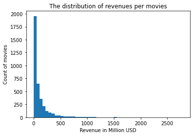

```python
plt.hist(df1['revenue'], bins=50);
plt.xlabel('Revenue in Million USD')
plt.ylabel('Count of movies')
plt.title('The distribution of revenues per movies')
```

**Lets look at the average revenue per month**

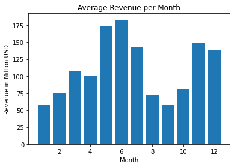

```python
month=range(1,13,1)
def target(par1):
    y=[]
    for i in range(1,13,1):
           y.append(df1[df1['release_date'].dt.month==i][par1].mean())

    return y
plt.bar(month,target('revenue'))
plt.xlabel('Month')
plt.ylabel('Revenue in Million USD')
plt.title('Average Revenue per Month')
plt.show()
```

[output not shown]

This is the average budget per month

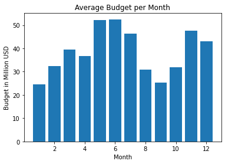

```python
plt.bar(month,target('budget'))
plt.xlabel('Month')
plt.ylabel('Budget in Million USD')
plt.title('Average Budget per Month')
plt.show()
```

Almost the same pattern is observed. But this could mean that movies in these dates have a higher or a lower count that might be skewing the average

**Lets look at the count of movies released each month**

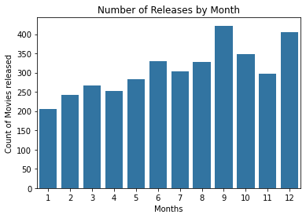

```python
color = sns.color_palette()[0]
df1['month'] = df1['release_date'].dt.month
sns.countplot(x=df1['month'], color = color );
plt.xlabel('Months');
plt.ylabel('Count of Movies released');
plt.title('Number of Releases by Month');
```

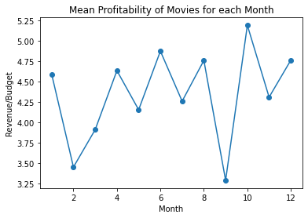

```python
plt.plot(month,target('ratio'), marker ='o')
plt.xlabel('Month')
plt.ylabel('Revenue/Budget')
plt.title('Mean Profitability of Movies for each Month')
plt.show()
```

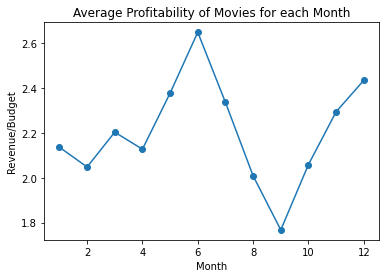

```python
df_plot = df1[(df1['ratio']>= -2.3) & (df1['ratio']<= 7.035)]
ratio_per_month=[]
for i in range(1,13,1):
    ratio_per_month.append(df_plot[df_plot['release_date'].dt.month==i]['ratio'].mean())

plt.plot(month,ratio_per_month, marker ='o')
plt.xlabel('Month')
plt.ylabel('Revenue/Budget')
plt.title('Average Profitability of Movies for each Month')
plt.show()
```

**Now this makes perfect sense, which describes why movies in June and December have higher profitability**  
Lets plot the above graph with median instead of mean to compare with median values:

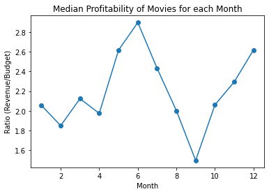

```python
def target2(par1):
    x=[]
    for i in range(1,13,1):
        x.append(df1[df1['release_date'].dt.month==i][par1].median())
    return x

plt.plot(month,target2('ratio'), marker ='o')
plt.xlabel('Month')
plt.ylabel('Ratio (Revenue/Budget)')
plt.title('Median Profitability of Movies for each Month')
plt.show()
```

BONUS CHECK:  
Almost identical which begs the question, is the median a better representation than the mean for these values  
Lets look at the average revenue per month looking at the median instead of the mean:

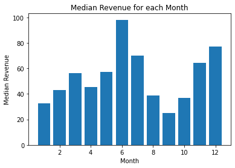

```python
plt.bar(month,target2('revenue'))
plt.xlabel('Month')
plt.ylabel('Median Revenue')
plt.title('Median Revenue for each Month')
plt.show()
```

Also lets look at the rate of the outliers vs time

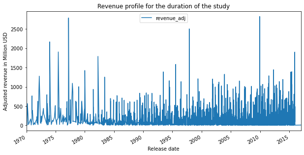

```python
df1.plot(x='release_date', y='revenue_adj', figsize=(10,5), xlim= ('1/1/1970','1/1/2017'));
plt.xlabel('Release date');
plt.ylabel('Adjusted revenue in Million USD');
plt.title('Revenue profile for the duration of the study')
```

### Research Question 3 : Do movies with higher budgets tend to be rated higher or be more popular?

**Lets look at pearson correlation coefficient along with the plot between budget and average vote :**

```
The Correlation is:
```

```
0.0135157614242886
```

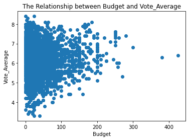

```python
def relation(x1,y1):
    plt.scatter(x=df1[x1], y=df1[y1]);
    plt.xlabel(x1.title())
    plt.ylabel(y1.title())
    plt.title('The Relationship between {} and {}'.format(x1.title(),y1.title()))
    print('The Correlation is: ')
    return df1[x1].corr(df1[y1], method='pearson')
relation('budget','vote_average')
```

**There seems to no correlation between budget and the average vote on IMDB**

**Lets look at pearson correlation coefficient along with the plot between budget and popularity :**

```
The Correlation is:
```

```
0.43879308906268977
```

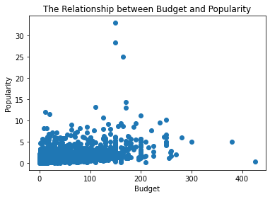

```python
relation('budget','popularity')
```

**There seems to be a moderate correlation between the Budget of the movie and its Popularity**

**Now lets look at the correlation between the Revenue and the Average vote on IMDB:**

```
The Correlation is:
```

```
0.22584106779557453
```

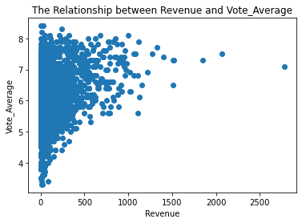

```python
relation('revenue','vote_average')
```

**There seems to be a weak correlation between Revenue and the Average vote on IMDB**

**Lets look at the correlation between the Popularity and the Revenue:**

```
The Correlation is:
```

```
0.6110809457211561
```

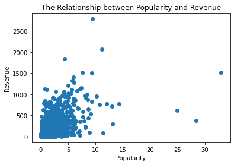

```python
relation('popularity','revenue')
```

**There seems to be a strong correlation between Popularity and the Revenue**

**Finally, lets look at the correlation between the Budget and the Revenue:**

```
The Correlation is:
```

```
0.684463028457562
```

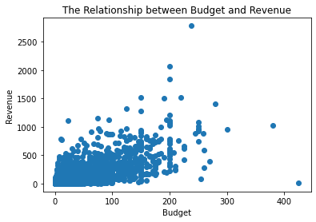

```python
relation('budget','revenue')
```

**There seems to be a strong correlation between the Budget and the Revenue**

## Conclusions

#### Regarding Question 1:

- The top performing actors have starred in movies over 10 times the average
- The top performing directors have directed movies higher than 5 to 12 times the average directors
- The top 20 actors by revenue are not the same as top 20 by number of movies
- The top 20 by adjusted revenue includes actors from the 70s and 80s which were not included in the original list, along with their order, making Harrison Ford is the most successful actor of all time
- Steven Spielberg's movies have higher than double the second in the all-time list which is James Cameron

#### Regarding Question 2:

- Most movies have revenues less than 50 Million USD
- For a film maker, the best time to release your movie is June, followed by December or May
- For a film maker, the least profitable time to release your movie is September, August and February respectively

#### Regarding Question 3:

- Highly rated movies are not necessarily popular movies and vice versa
- Popularity positively affects the revenue of the movie
- For a film maker, higher budget movies are correlated with higher revenues

#### Limitations:

- Movies with missing values for revenues, budgets or actors have been dropped from the dataset which must have affected the statistics computed
- Actor revenues aggregates the sum of all the movies he appeared in which is not accurate
- Actor revenues is only aggregated if their names were one of the first three names
- Actor Movie count is only calculated if their names were one of the first three names
- Movies with a cast like Avengers and Starwars where there are a lot of main characters have not been accredited to the full main cast

#### Further Work:

- Average vote should have a minimum vote count to avoid outliers
- The combination of Actor/Director along with the revenue could be insightful
- Actors and directors could be divided into categories each having their own statistics
- Movies could be aggregated based on Genres and Production companies with an analysis of revenue/ budget per genre/production company, which would be insightful
- If the revenue could be divided into US and Abroad, will generate a completely different outlook